# Case Study 1

#### Describe the dataset and any issues with it.

```python
#importing required libraries
import pandas as pd
import matplotlib.pyplot as plt
import seaborn as sns
```

```python
#reading data from csv file
df = pd.read_csv("loans_full_schema.csv")
df.head()
```

|  | emp_title | emp_length | state | homeownership | annual_income | verified_income | debt_to_income | annual_income_joint | verification_income_joint | debt_to_income_joint | ... | sub_grade | issue_month | loan_status | initial_listing_status | disbursement_method | balance | paid_total | paid_principal | paid_interest | paid_late_fees |
| --- | --- | --- | --- | --- | --- | --- | --- | --- | --- | --- | --- | --- | --- | --- | --- | --- | --- | --- | --- | --- | --- |
| 0 | global config engineer | 3.0 | NJ | MORTGAGE | 90000.0 | Verified | 18.01 | NaN | NaN | NaN | ... | C3 | Mar-2018 | Current | whole | Cash | 27015.86 | 1999.33 | 984.14 | 1015.19 | 0.0 |
| 1 | warehouse office clerk | 10.0 | HI | RENT | 40000.0 | Not Verified | 5.04 | NaN | NaN | NaN | ... | C1 | Feb-2018 | Current | whole | Cash | 4651.37 | 499.12 | 348.63 | 150.49 | 0.0 |
| 2 | assembly | 3.0 | WI | RENT | 40000.0 | Source Verified | 21.15 | NaN | NaN | NaN | ... | D1 | Feb-2018 | Current | fractional | Cash | 1824.63 | 281.80 | 175.37 | 106.43 | 0.0 |
| 3 | customer service | 1.0 | PA | RENT | 30000.0 | Not Verified | 10.16 | NaN | NaN | NaN | ... | A3 | Jan-2018 | Current | whole | Cash | 18853.26 | 3312.89 | 2746.74 | 566.15 | 0.0 |
| 4 | security supervisor | 10.0 | CA | RENT | 35000.0 | Verified | 57.96 | 57000.0 | Verified | 37.66 | ... | C3 | Mar-2018 | Current | whole | Cash | 21430.15 | 2324.65 | 1569.85 | 754.80 | 0.0 |

5 rows × 55 columns

```python
#checking dimension of data
df.shape
```

```
(10000, 55)
```

```python
#summary of data
df.describe()
```

|  | emp_length | annual_income | debt_to_income | annual_income_joint | debt_to_income_joint | delinq_2y | months_since_last_delinq | earliest_credit_line | inquiries_last_12m | total_credit_lines | ... | public_record_bankrupt | loan_amount | term | interest_rate | installment | balance | paid_total | paid_principal | paid_interest | paid_late_fees |
| --- | --- | --- | --- | --- | --- | --- | --- | --- | --- | --- | --- | --- | --- | --- | --- | --- | --- | --- | --- | --- | --- |
| count | 9183.000000 | 1.000000e+04 | 9976.000000 | 1.495000e+03 | 1495.000000 | 10000.00000 | 4342.000000 | 10000.00000 | 10000.00000 | 10000.000000 | ... | 10000.000000 | 10000.000000 | 10000.000000 | 10000.000000 | 10000.000000 | 10000.000000 | 10000.000000 | 10000.000000 | 10000.000000 | 10000.000000 |
| mean | 5.930306 | 7.922215e+04 | 19.308192 | 1.279146e+05 | 19.979304 | 0.21600 | 36.760709 | 2001.29000 | 1.95820 | 22.679600 | ... | 0.123800 | 16361.922500 | 43.272000 | 12.427524 | 476.205323 | 14458.916610 | 2494.234773 | 1894.448466 | 599.666781 | 0.119516 |
| std | 3.703734 | 6.473429e+04 | 15.004851 | 7.016838e+04 | 8.054781 | 0.68366 | 21.634939 | 7.79551 | 2.38013 | 11.885439 | ... | 0.337172 | 10301.956759 | 11.029877 | 5.001105 | 294.851627 | 9964.561865 | 3958.230365 | 3884.407175 | 517.328062 | 1.813468 |
| min | 0.000000 | 0.000000e+00 | 0.000000 | 1.920000e+04 | 0.320000 | 0.00000 | 1.000000 | 1963.00000 | 0.00000 | 2.000000 | ... | 0.000000 | 1000.000000 | 36.000000 | 5.310000 | 30.750000 | 0.000000 | 0.000000 | 0.000000 | 0.000000 | 0.000000 |
| 25% | 2.000000 | 4.500000e+04 | 11.057500 | 8.683350e+04 | 14.160000 | 0.00000 | 19.000000 | 1997.00000 | 0.00000 | 14.000000 | ... | 0.000000 | 8000.000000 | 36.000000 | 9.430000 | 256.040000 | 6679.065000 | 928.700000 | 587.100000 | 221.757500 | 0.000000 |
| 50% | 6.000000 | 6.500000e+04 | 17.570000 | 1.130000e+05 | 19.720000 | 0.00000 | 34.000000 | 2003.00000 | 1.00000 | 21.000000 | ... | 0.000000 | 14500.000000 | 36.000000 | 11.980000 | 398.420000 | 12379.495000 | 1563.300000 | 984.990000 | 446.140000 | 0.000000 |
| 75% | 10.000000 | 9.500000e+04 | 25.002500 | 1.515455e+05 | 25.500000 | 0.00000 | 53.000000 | 2006.00000 | 3.00000 | 29.000000 | ... | 0.000000 | 24000.000000 | 60.000000 | 15.050000 | 644.690000 | 20690.182500 | 2616.005000 | 1694.555000 | 825.420000 | 0.000000 |
| max | 10.000000 | 2.300000e+06 | 469.090000 | 1.100000e+06 | 39.980000 | 13.00000 | 118.000000 | 2015.00000 | 29.00000 | 87.000000 | ... | 3.000000 | 40000.000000 | 60.000000 | 30.940000 | 1566.590000 | 40000.000000 | 41630.443684 | 40000.000000 | 4216.440000 | 52.980000 |

8 rows × 42 columns

```python
#checking info of data
df.info()
```

```
<class 'pandas.core.frame.DataFrame'>
RangeIndex: 10000 entries, 0 to 9999
Data columns (total 55 columns):
 #   Column                            Non-Null Count  Dtype
---  ------                            --------------  -----
 0   emp_title                         9167 non-null   object
 1   emp_length                        9183 non-null   float64
 2   state                             10000 non-null  object
 3   homeownership                     10000 non-null  object
 4   annual_income                     10000 non-null  float64
 5   verified_income                   10000 non-null  object
 6   debt_to_income                    9976 non-null   float64
 7   annual_income_joint               1495 non-null   float64
 8   verification_income_joint         1455 non-null   object
 9   debt_to_income_joint              1495 non-null   float64
```

[output cut: 47 more lines]

```python
#columns with null values
a = df.isnull().sum() > 0
df.loc[:,a.values].isnull().sum()
```

```
emp_title                            833
emp_length                           817
debt_to_income                        24
annual_income_joint                 8505
verification_income_joint           8545
debt_to_income_joint                8505
months_since_last_delinq            5658
months_since_90d_late               7715
months_since_last_credit_inquiry    1271
num_accounts_120d_past_due           318
dtype: int64
```

```python
#removing columns with too many null values and with too many categories
df2 = df.drop(columns = ['emp_title', 'emp_length', 'annual_income_joint', 'verification_income_joint', 'debt_to_income_joint',
                        'months_since_last_delinq', 'months_since_90d_late', 'months_since_last_credit_inquiry',
                        'num_accounts_120d_past_due', 'state', 'sub_grade'])
```

In above cells, I removed all the columns with too many null values and also the columns with too many categories, because some machine learning algortihms required to convert data into numeric and columns with too many categories can make the data messy in this case.

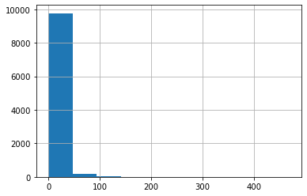

```python
#plotting distribution of debt to income
df2['debt_to_income'].hist();
```

From above plot, the distribution of debt_to_income is right skewed so median value would be better option to fill null values instead of mean value.

```python
#filling null values with median value of debt to income
df2['debt_to_income'].fillna(df['debt_to_income'].median(), inplace = True)
```

##### Generate a minimum of 5 unique visualizations using the data and write a brief description of your observations. Additionally, all attempts should be made to make the visualizations visually appealing.

Since I have to predict the interest_rate columns, so all visualization will be related to the relation of interest_rate with other predictors.

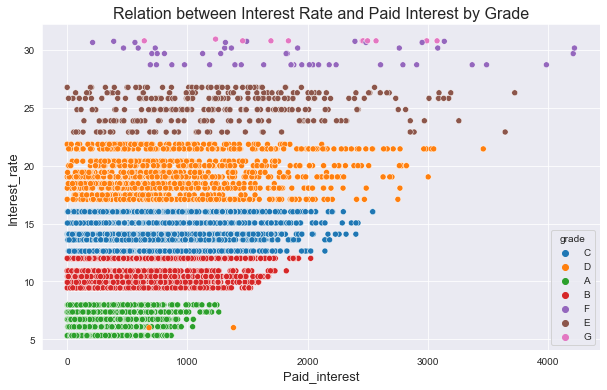

```python
#plotting relation between interest_rate and paid_interes
sns.set_style("darkgrid")
plt.figure(figsize = (10, 6))
sns.scatterplot(x = "paid_interest", y = "interest_rate", data = df2, hue = "grade")
plt.title("Relation between Interest Rate and Paid Interest by Grade", fontsize = 16)
plt.xlabel("Paid_interest", fontsize = 13)
plt.ylabel("Interest_rate", fontsize = 13)
plt.show()
```

From above plot, it can be observed that there is a positive relation between Paid interest and Interest Rate as the value of Interest Rate increased with increase in Paid Interest. The plot shows that for Grade A, the value of paid interest and interest rate is lowest followed by grade B, C and D. The plot also shows that for grade G the value of interest rate and paid interest is highest followed by grade F and grade E.

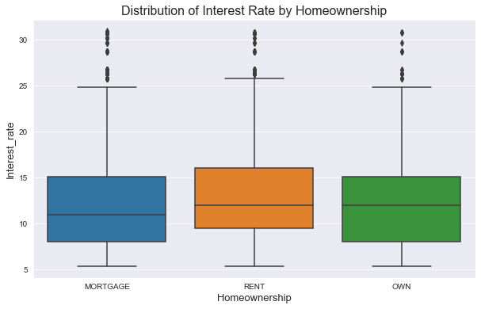

```python
#plotting relation between interest rate and homeowner ship
plt.figure(figsize = (10, 6))
sns.boxplot(x = "homeownership", y = "interest_rate", data = df2)
plt.title("Distribution of Interest Rate by Homeownership", fontsize = 16)
plt.xlabel("Homeownership", fontsize = 13)
plt.ylabel("Interest_rate", fontsize = 13)
plt.show()
```

From above plot, it can be observed that the average value of interest rate is lowest for MORTGAGE type homeownership followed by OWN homeowner shipt. The plot shows that the interest rate is highest for RENT homeownership. There are outliers with pretty high value of Interest rate for all MORTGAGE, RENT, OWN type homeownership.

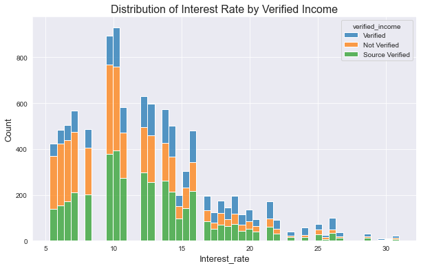

```python
#plotting distribution of Interest rate by loan_status
plt.figure(figsize = (10, 6))
sns.histplot(x = "interest_rate", hue = "verified_income", data = df2, multiple = "stack")
plt.title("Distribution of Interest Rate by Verified Income", fontsize = 16)
plt.xlabel("Interest_rate", fontsize = 13)
plt.ylabel("Count", fontsize = 13)
plt.show()
```

From above plot, it can be seen that the distribution of interest rate is right skewed as most of the observations have Interest rate values between 5 to 20. Most of the Source verified observations have interest rate between 5-15 there are also observations with source verified and have interest rate greater than 15. Most of the Not veriefied observations also have Interst rate values between 5 to almost 13. For overall interest rate there are many outliers with pretty extreme values between 25 to 32 too.

```python
df2.groupby("loan_purpose")["interest_rate"].mean().sort_values()
```

```
loan_purpose
house                 11.369868
credit_card           11.432343
home_improvement      11.620309
major_purchase        11.966271
car                   12.038015
medical               12.151173
other                 12.425766
small_business        13.002560
debt_consolidation    13.009541
moving                13.167246
vacation              13.330161
renewable_energy      13.543000
Name: interest_rate, dtype: float64
```

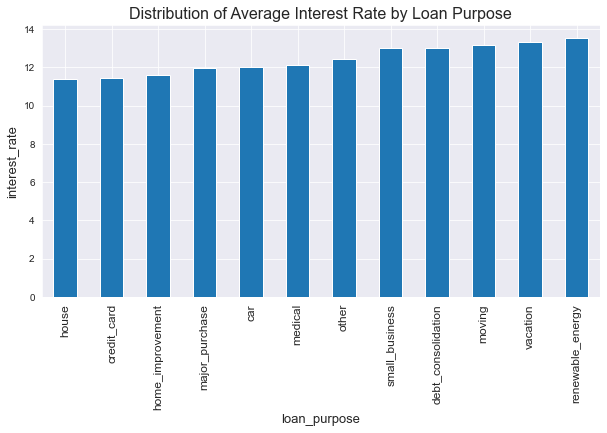

```python
#Distribution of average Interest rate by loan_purpose
df2.groupby("loan_purpose")["interest_rate"].mean().sort_values().plot(kind = "bar", figsize = (10, 5))
plt.title("Distribution of Average Interest Rate by Loan Purpose", fontsize = 16)
plt.xlabel("loan_purpose", fontsize = 13)
plt.ylabel("interest_rate", fontsize = 13)
plt.xticks(rotation =90, fontsize = 12)
plt.show()
```

From above plot, it is pretty evident that for house loan_purpose the average interest is lowest followed by credit_card, home_improvement, major_purchase and car loan_purposes. The plot also shows that for renewable_energy the average interest rate is highest followed by vacation, moving and debt consolidation.

[figure not shown]

```python
#distribution of Interest rate by issue_month
plt.figure(figsize = (10, 5))
sns.violinplot(x = "loan_status", y = "interest_rate", data = df2)
plt.title("Distribution of Interest Rate by Issue Month", fontsize = 16)
plt.xlabel("issue_month", fontsize = 13)
plt.ylabel("interest_rate", fontsize = 13)
plt.show()
```

From above plot, I observed that for loan status charged off, the average Interest rate is lowest followed by current loan status, and FUll paid loan status. The plot also shows that for loan status Late(31-120) days, the average interest rate is highest followed by Late(16-30) days and In Grace Period. There are some outliers with pretty high value of interest rate for Current, Fully Paid, and Late(31-120 days) loan status.

#### Create a feature set and create a model which predicts interest_rate using at least 2 algorithms.

```python
#### correlation matrix for numerical variables
plt.figure(figsize = (12, 12))
df2.select_dtypes(exclude = 'object').corr()['interest_rate']
```

```
annual_income                  -0.099584
debt_to_income                  0.141273
delinq_2y                       0.090456
earliest_credit_line            0.103635
inquiries_last_12m              0.131193
total_credit_lines             -0.044435
open_credit_lines              -0.012773
total_credit_limit             -0.130497
total_credit_utilized           0.031527
num_collections_last_12m        0.029901
num_historical_failed_to_pay    0.037563
current_accounts_delinq         0.007184
total_collection_amount_ever    0.013532
current_installment_accounts    0.047131
accounts_opened_24m             0.120657
num_satisfactory_accounts      -0.013330
num_accounts_30d_past_due       0.007184
num_active_debit_accounts       0.026800
total_debit_limit              -0.254225
num_total_cc_accounts          -0.071238
num_open_cc_accounts           -0.028891
num_cc_carrying_balance         0.081741
num_mort_accounts              -0.138351
account_never_delinq_percent   -0.124702
tax_liens                       0.016547
public_record_bankrupt          0.047477
loan_amount                     0.064527
term                            0.358664
interest_rate                   1.000000
installment                     0.098811
balance                         0.067570
paid_total                      0.065339
paid_principal                 -0.001953
paid_interest                   0.514508
paid_late_fees                  0.023110
Name: interest_rate, dtype: float64
```

```python
#selecting significant features only
df2 = df2[['paid_interest', 'term', 'account_never_delinq_percent', 'total_debit_limit',
           'accounts_opened_24m', 'total_credit_limit', 'inquiries_last_12m', 'earliest_credit_line', 'debt_to_income',
          'homeownership', 'verified_income', 'loan_purpose', 'application_type', 'grade', 'loan_status', 'initial_listing_status',
          'disbursement_method', "interest_rate"]]
```

After selecting the features set, now I will convert all categorical variable into numerical by dummy variable technique and then will split the data into train and test data. The training data will be used for fitting the model and testing data will be used for checking the performance of the model.

```python
#converting categorical variables into numerical variables
df2_num = pd.get_dummies(df2, drop_first = True)
#separating input and output features
X = df2_num.drop(columns = "interest_rate")
y = df["interest_rate"]
```

```python
#splitting data into train and test data
from sklearn.model_selection import train_test_split
X_train, X_test, y_train, y_test = train_test_split(X, y, test_size = 0.3, random_state = 42)
```

#### Linear Regression Model

```python
#Initializing and fitting linear regression model
from sklearn.linear_model import LinearRegression
lr = LinearRegression()
lr.fit(X_train, y_train)
```

```
LinearRegression()
```

```python
#making predictions on test data
lr_preds = lr.predict(X_test)
```

```python
#mean square error on test data
from sklearn.metrics import mean_squared_error
lr_mse = round(mean_squared_error(y_test, lr_preds), 3)
lr_mse
```

```
1.14
```

The mean squared error value of Linear Regression model is 1.14 which is pretty good which means the model fits and generalize well to the data and can be used for predicting interest rate in future.

#### Random Forest Regressor

```python
#Initializing and fitting Random Forest model
from sklearn.ensemble import RandomForestRegressor
rfc = RandomForestRegressor(random_state = 42)
rfc.fit(X_train, y_train)
```

```
RandomForestRegressor(random_state=42)
```

```python
#Making predictions on test data
rfc_preds = rfc.predict(X_test)
```

```python
#mean squared error of random forest model
rfc_mse = round(mean_squared_error(y_test, rfc_preds), 2)
rfc_mse
```

```
1.16
```

The mean square error of Random Forest model is slightly high as compare to the mean square error of Linear Regression model.

#### Describe any data cleansing that must be performed and analysis when examining the data. Visualize the test results and propose enhancements to the model, what would you do if you had more time. Also describe assumptions you made and your approach.

Since the mean squared error for Linear Regression model is lower as compare to the Random Forest Regressor, so I concluded that the Linear regression model fits and genralize well to the data and perform better as compare to the Random Forest Regressor and can be used for making prdictions in future. Now, I will visualize the actual vs predicted values for linear regression model.

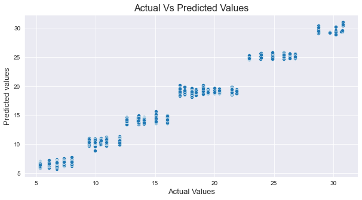

```python
#plotting actual vs predicted values for Linear Regression Model
plt.figure(figsize = (10,5))
sns.scatterplot(x = y_test, y = lr_preds)
plt.title("Actual Vs Predicted Values", fontsize = 16)
plt.xlabel("Actual Values", fontsize = 13)
plt.ylabel("Predicted values", fontsize = 13)
plt.show()
```

From above plot, it can be seen that the actual and predicted values followed the lienar straight line which means Linear Regression model performs well on the data and can be used for making predictions in future.

If I had more time, I would have tried more and more models to find an optimal model. I would have tuned the hyperparameters of different models to increase the performance of the model. I would have explored the relation of all features with interest rate and would have used only those predictors that have significant relation with interest rate. There are few assumptions for my final model that the residuals are normally distrubited, the linearity of the data and homegenity of variance in the data.